# Kümeleme Analizleri ve Uygulamaları

## Benzerlik ve/veya Uzaklık Matrislerinin Oluşturulması

Benzerlik matrisi:

```r
# Benzerlik matrisi
dist.eucl <-dist(data.scaled, method = "euclidean")
dim(dist.eucl)
```

[output not shown]

```r
head(dist.eucl)
```

```
## [1] 1.1722914 0.8427840 1.0999999 0.2592702 1.0349769 0.6591230
```

## Kümeleme Algoritmaları

### k-ortalamalar Kümelemesi

Özellikleri:

- Klinik problemlerin çözümünde hiyerarşik kümeleme algoritması kadar yaygın kullanılır.
- Partition algoritmasını kullanır.
- Her kümenin merkezi tarafından sunulan uzaklık-tabanlı bir algoritmadır.
- Ahlqvist ve ark. beş değişkeni temel alarak diyabetik bireyleri tabakalamak için hiyerarşik kümelemeye ek olarak k-means uygulaması kullandı.
- Kalp yetmezliği hastalarının sınıflandırılması ve bir k-ortalama kümeleme algoritmasının kullanılması ile ilgili olarak, Ahmad ve ark.sadece sonuçlarda değil, aynı zamanda terapötiklere yanıtta da önemli ölçüde farklılık gösteren dört klinik farklı fenotip tanımladı.

R paketleri:

- Stats::kmeans() (Sadece Öklid uzaklığını kullanır ve sadece sayısal değişkenler için)
- amap::kmeans() (Sadece sayısal değişkenleri kullanır ancak, Öklid ten farklı bir uzaklık ölçüsü seçebilir.)
- clustMixType (Karışık veri türlerini kabul eder)

Avantajları:

- Uygulamak ve anlamak basit
- Büyük veri setleri için hızlı ve etkili

Dezvantajları:

- Küme sayılarının belirlenmesi gerekliliği
- Rastgele seçilen merkezlere duyarlılık
- Bazı uygulamaların sadece Öklid uzaklığını kullanması

Veri setine k-ortalamalar kümelemesi uygulanırken öncelikle optimum küme sayısı bulunur.

1. Optimum küme sayısı (Elbow yöntemi):

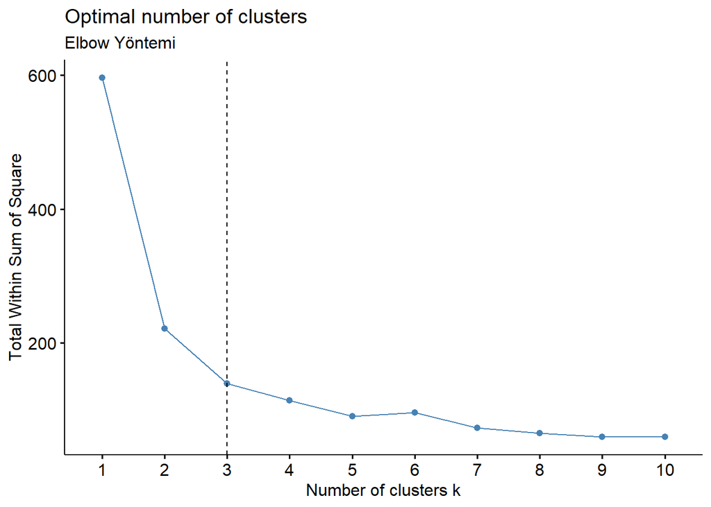

```r
# Elbow yöntemi

fviz_nbclust(data.scaled, kmeans, method = "wss")+
geom_vline(xintercept = 3, linetype = 2)+labs(subtitle = "Elbow Yöntemi")
```

2. Optimum küme sayısı (Silhouette yöntemi):

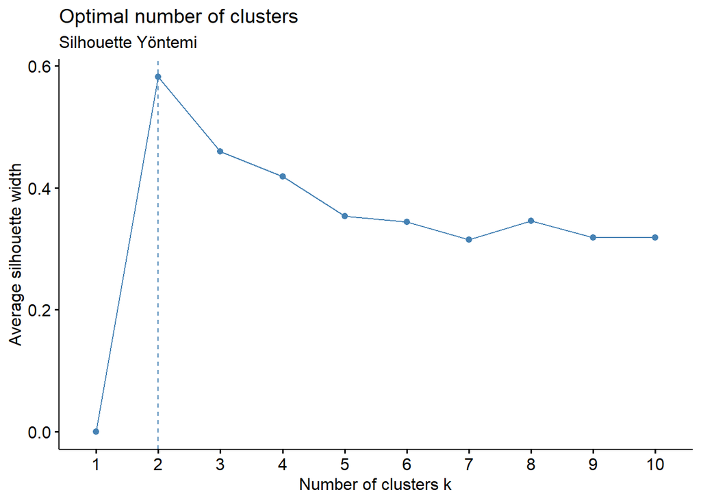

```r
# Silhouette yöntemi
fviz_nbclust(data.scaled, kmeans, method = "silhouette")+labs(subtitle = "Silhouette Yöntemi")
```

3. Optimum küme sayısı (Gap istatistiği):

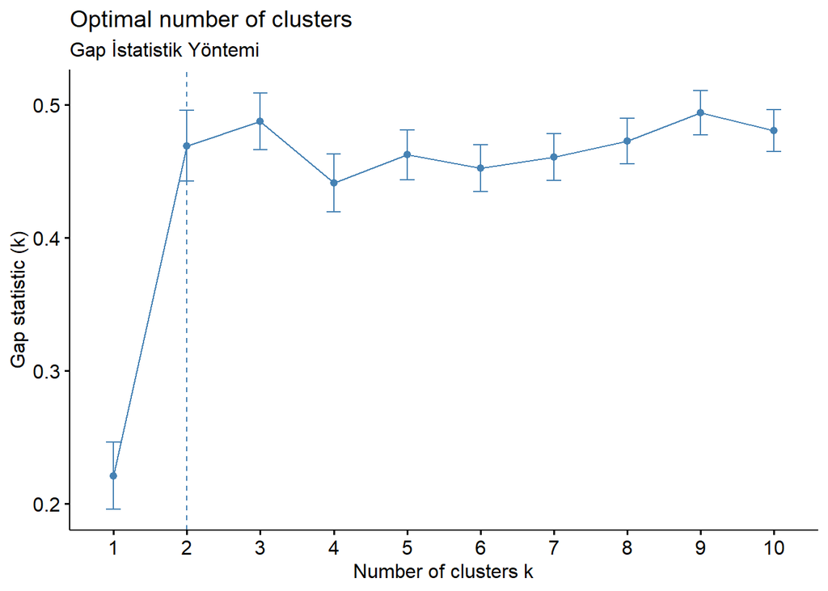

```r
# Gap istatistiği
set.seed(123)
fviz_nbclust(data.scaled, kmeans, nstart = 25, method = "gap_stat", nboot = 50)+labs(subtitle = "Gap İstatistik Yöntemi")
```

4. Optimum küme sayısı (NbClust() yöntemi):

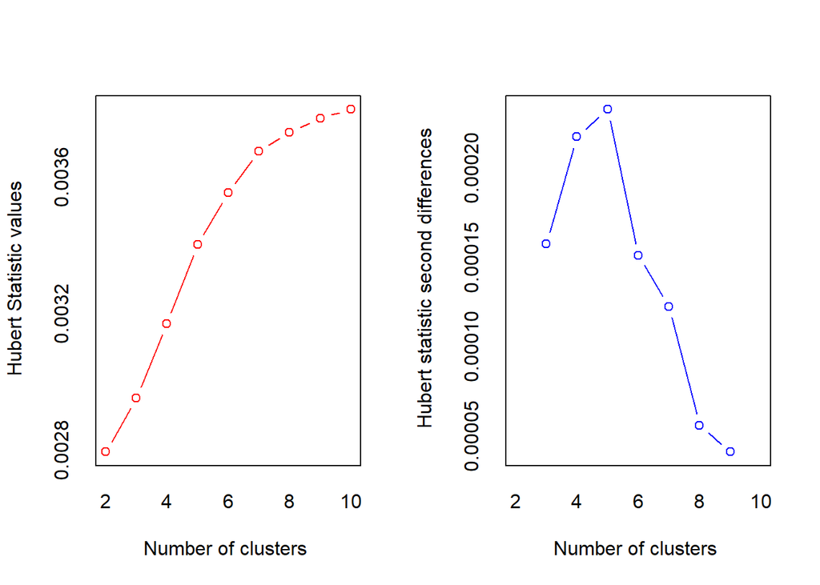

```
## *** : The Hubert index is a graphical method of determining the number of clusters.
##                 In the plot of Hubert index, we seek a significant knee that corresponds to a
##                 significant increase of the value of the measure i.e the significant peak in Hubert
##                 index second differences plot.
##
```

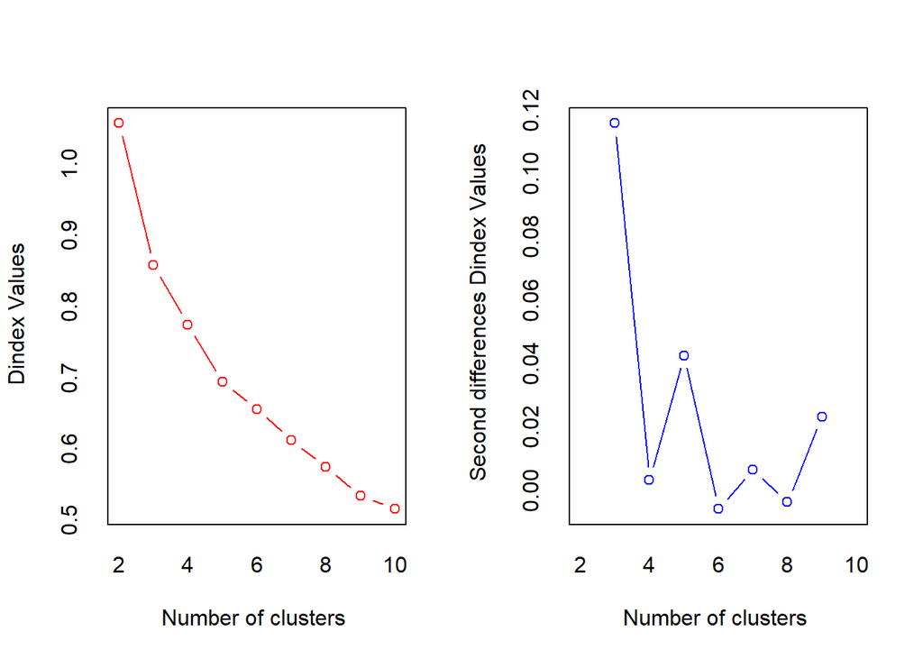

```
## *** : The D index is a graphical method of determining the number of clusters.
##                 In the plot of D index, we seek a significant knee (the significant peak in Dindex
##                 second differences plot) that corresponds to a significant increase of the value of
##                 the measure.
##
## * Among all indices:
## * 11 proposed 2 as the best number of clusters
## * 10 proposed 3 as the best number of clusters
## * 1 proposed 4 as the best number of clusters
## * 1 proposed 6 as the best number of clusters
## * 1 proposed 10 as the best number of clusters
##
##                    ***** Conclusion *****
##
## * According to the majority rule, the best number of clusters is  2
##
##
```

```r
nb <- NbClust(as.matrix(data.scaled[,-c(5)]), distance = "euclidean", min.nc = 2, max.nc = 10, method = "kmeans", index = "all")
```

```r
# Sonuçlar
nb
```

```
## $All.index
##        KL       CH Hartigan    CCC    Scott   Marriot    TrCovW   TraceW
## 2  3.9498 251.3493  87.3699 3.3595 357.8871 1471010.8 1643.9577 220.8793
## 3  5.1669 241.9044  33.1486 5.1886 489.5281 1376126.9 1225.4423 138.8884
## 4  0.5567 207.2659  37.4374 3.6814 555.6392 1574434.9  705.5542 113.3319
## 5  3.5421 203.2674  19.5911 3.5789 652.9526 1285860.3  667.4659  90.2022
## 6  0.7874 187.2031  19.0351 3.3533 720.9245 1176948.3  510.6882  79.4655
## 7  1.1988 178.5481  16.2779 3.4533 763.2771 1207890.6  394.3442  70.1876
## 8  0.5699 171.5792  20.5630 3.5166 846.4971  905868.3  351.9925  63.0146
## 9  2.1882 173.2143  13.2186 4.2469 921.2836  696371.3  222.4485  55.0437
## 10 1.1910 168.6666   2.3371 4.3223 945.2575  732730.5  185.9404  50.3257
##    Friedman   Rubin Cindex     DB Silhouette   Duda Pseudot2   Beale Ratkowsky
## 2   50.5461  2.6983 0.2709 0.6828     0.5818 1.9311 -48.6978 -1.1403    0.5535
## 3   58.5837  4.2912 0.2428 0.9141     0.4599 0.4603  56.2860  2.7732    0.5028
## 4   61.9721  5.2589 0.3474 0.9814     0.3869 0.9204   4.3246  0.2048    0.4491
## 5   67.5363  6.6074 0.3598 1.0526     0.3455 2.2695 -31.8842 -1.2891    0.4114
## 6   77.5691  7.5001 0.3307 1.1560     0.3266 0.5343  27.0234  2.0266    0.3797
## 7   78.2758  8.4915 0.3177 1.1076     0.3254 0.6799  14.1232  1.0960    0.3548
## 8   86.3269  9.4581 0.2989 1.1326     0.3227 1.8821 -14.9977 -1.0719    0.3341
## 9   95.0688 10.8278 0.2730 1.0595     0.3388 0.9118   3.4826  0.2219    0.3174
## 10  94.7241 11.8429 0.2580 1.0584     0.3377 1.4544  -8.1230 -0.7071    0.3025
##        Ball Ptbiserial   Frey McClain   Dunn Hubert SDindex Dindex   SDbw
## 2  110.4396     0.7815 1.4732  0.3492 0.2674 0.0028  1.5703 1.0566 0.4276
## 3   46.2961     0.6797 2.0078  0.7938 0.0265 0.0030  1.8139 0.8573 0.5612
## 4   28.3330     0.6245 0.6583  1.0201 0.0399 0.0032  1.7904 0.7738 0.4574
## 5   18.0404     0.5905 0.7997  1.2718 0.0808 0.0034  1.8372 0.6936 0.2555
## 6   13.2443     0.5556 0.9092  1.5025 0.0842 0.0036  2.3072 0.6558 0.2588
## 7   10.0268     0.5340 0.9015  1.6553 0.0912 0.0037  2.2470 0.6120 0.1772
## 8    7.8768     0.4992 0.6392  1.9329 0.0861 0.0037  2.5635 0.5747 0.1510
## 9    6.1160     0.4624 0.2551  2.2801 0.0861 0.0038  2.6276 0.5336 0.1361
## 10   5.0326     0.4561 1.8980  2.3325 0.0861 0.0038  2.5478 0.5155 0.1257
##
## $All.CriticalValues
##    CritValue_Duda CritValue_PseudoT2 Fvalue_Beale
## 2          0.5551            80.9487       1.0000
## 3          0.5551            38.4707       0.0284
## 4          0.5633            38.7617       0.9355
## 5          0.4195            78.8634       1.0000
## 6          0.4590            36.5375       0.0961
## 7          0.4656            34.4267       0.3624
```

[output cut: 9 more lines]

```
## Number_clusters  3.0000   6.0000  3.0000 3.0000 2.0000     2.0000 2.0000
## Value_Index     56.4345  10.0327 -0.6252 0.2428 0.6828     0.5818 1.9311
##                 PseudoT2   Beale Ratkowsky    Ball PtBiserial   Frey McClain
## Number_clusters   2.0000  2.0000    2.0000  3.0000     2.0000 3.0000  2.0000
## Value_Index     -48.6978 -1.1403    0.5535 64.1435     0.7815 2.0078  0.3492
##                   Dunn Hubert SDindex Dindex    SDbw
## Number_clusters 2.0000      0  2.0000      0 10.0000
## Value_Index     0.2674      0  1.5703      0  0.1257
##
## $Best.partition
##   [1] 1 1 1 1 1 1 1 1 1 1 1 1 1 1 1 1 1 1 1 1 1 1 1 1 1 1 1 1 1 1 1 1 1 1 1 1 1
##  [38] 1 1 1 1 1 1 1 1 1 1 1 1 1 2 2 2 2 2 2 2 2 2 2 2 2 2 2 2 2 2 2 2 2 2 2 2 2
##  [75] 2 2 2 2 2 2 2 2 2 2 2 2 2 2 2 2 2 2 2 2 2 2 2 2 2 2 2 2 2 2 2 2 2 2 2 2 2
## [112] 2 2 2 2 2 2 2 2 2 2 2 2 2 2 2 2 2 2 2 2 2 2 2 2 2 2 2 2 2 2 2 2 2 2 2 2 2
## [149] 2 2
```

```r
table(nb$Best.nc[1,])
```

```
##
##  0  2  3  4  6 10
##  2 11 10  1  1  1
```

k-ortalamalar kümelemesinde center=3 ile küme sayısı 3 olarak belirlendi. nstarts seçeneği, çoklu ilk konfigürasyonları oluşturup, en iyi olanı raporlar.

```r
# k = 3 kümeye göre k-ortalamalar kümelemesi

set.seed(123)
km.res <- kmeans(data.scaled, centers = 3, nstart = 25)
str(km.res)
```

```
## List of 9
##  $ cluster     : int [1:150] 1 1 1 1 1 1 1 1 1 1 ...
##  $ centers     : num [1:3, 1:4] -1.0112 -0.0501 1.1322 0.8504 -0.8804 ...
##   ..- attr(*, "dimnames")=List of 2
##   .. ..$ : chr [1:3] "1" "2" "3"
##   .. ..$ : chr [1:4] "Sepal.Length" "Sepal.Width" "Petal.Length" "Petal.Width"
##  $ totss       : num 596
##  $ withinss    : num [1:3] 47.4 44.1 47.5
##  $ tot.withinss: num 139
##  $ betweenss   : num 457
##  $ size        : int [1:3] 50 53 47
##  $ iter        : int 2
##  $ ifault      : int 0
##  - attr(*, "class")= chr "kmeans"
```

```r
summary(km.res)
```

```
##              Length Class  Mode
## cluster      150    -none- numeric
## centers       12    -none- numeric
## totss          1    -none- numeric
## withinss       3    -none- numeric
## tot.withinss   1    -none- numeric
## betweenss      1    -none- numeric
## size           3    -none- numeric
## iter           1    -none- numeric
## ifault         1    -none- numeric
```

```r
km.res
```

```
## K-means clustering with 3 clusters of sizes 50, 53, 47
##
## Cluster means:
##   Sepal.Length Sepal.Width Petal.Length Petal.Width
## 1  -1.01119138  0.85041372   -1.3006301  -1.2507035
## 2  -0.05005221 -0.88042696    0.3465767   0.2805873
## 3   1.13217737  0.08812645    0.9928284   1.0141287
##
## Clustering vector:
##   [1] 1 1 1 1 1 1 1 1 1 1 1 1 1 1 1 1 1 1 1 1 1 1 1 1 1 1 1 1 1 1 1 1 1 1 1 1 1
##  [38] 1 1 1 1 1 1 1 1 1 1 1 1 1 3 3 3 2 2 2 3 2 2 2 2 2 2 2 2 3 2 2 2 2 3 2 2 2
##  [75] 2 3 3 3 2 2 2 2 2 2 2 3 3 2 2 2 2 2 2 2 2 2 2 2 2 2 3 2 3 3 3 3 2 3 3 3 3
## [112] 3 3 2 2 3 3 3 3 2 3 2 3 2 3 3 2 3 3 3 3 3 3 2 2 3 3 3 2 3 3 3 2 3 3 3 2 3
## [149] 3 2
##
## Within cluster sum of squares by cluster:
## [1] 47.35062 44.08754 47.45019
##  (between_SS / total_SS =  76.7 %)
##
## Available components:
##
## [1] "cluster"      "centers"      "totss"        "withinss"     "tot.withinss"
## [6] "betweenss"    "size"         "iter"         "ifault"
```

```r
table(km.res$cluster, iris[,5])
```

```
##
##     setosa versicolor virginica
##   1     50          0         0
##   2      0         39        14
##   3      0         11        36
```

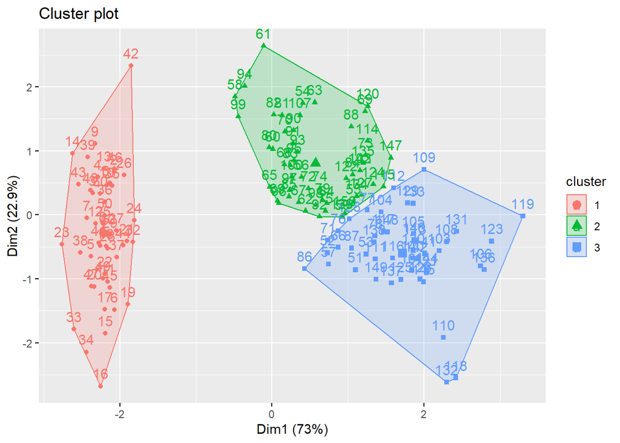

```r
# k-ortalamalar sonuçlarının görselleştirilmesi
fviz_cluster(km.res, data = data.scaled)
```

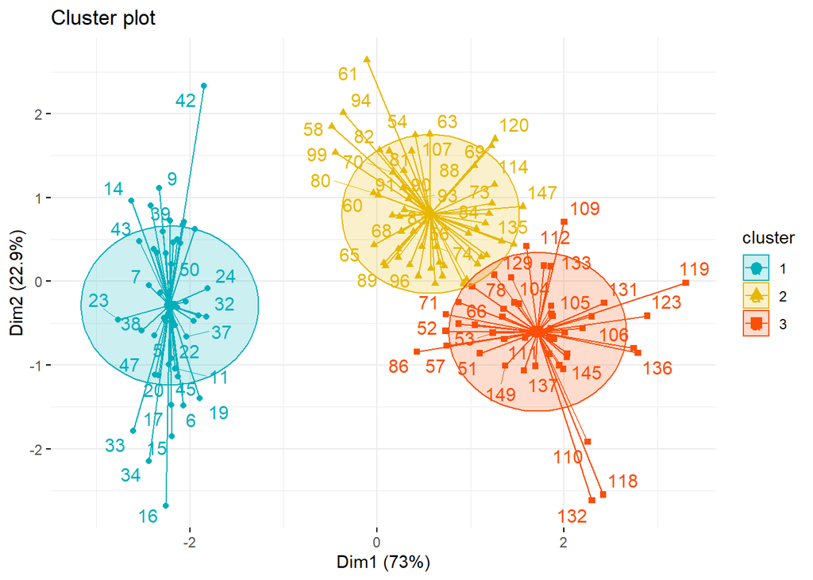

```r
# k-ortalamalar sonuçlarının görselleştirilmesi
fviz_cluster(km.res, data = data.scaled,
palette = c( "#00AFBB", "#E7B800", "#FC4E07"),
ellipse.type = "euclid",
star.plot = TRUE,
repel = TRUE,
ggtheme = theme_minimal())
```

Farklı küme sayıları ile k-ortalamalar algoritması grafikleri aşağıdaki kodlar ile gösterilir.

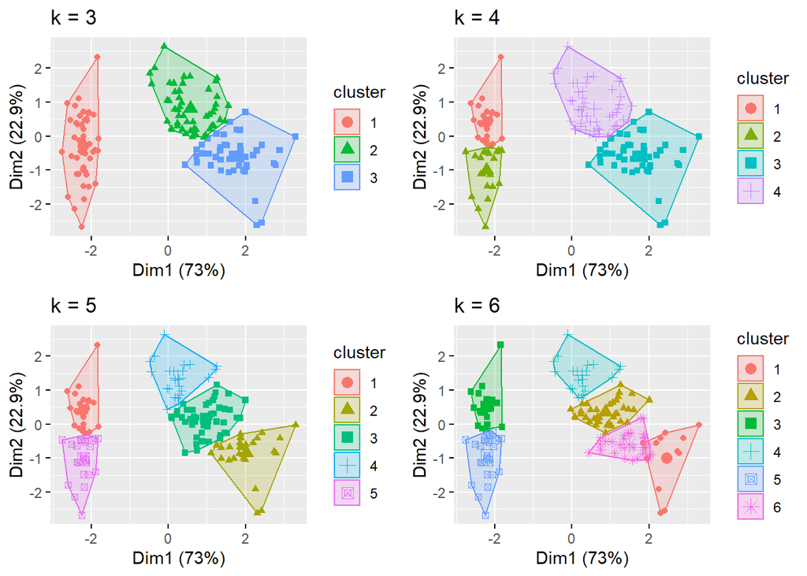

```r
k4 <- kmeans(data.scaled, centers = 4, nstart = 25)
k5 <- kmeans(data.scaled, centers = 5, nstart = 25)
k6 <- kmeans(data.scaled, centers = 6, nstart = 25)

# Grafikleri karşılaştır
p1 <- fviz_cluster(km.res, geom = "point", data = data.scaled) + ggtitle("k = 3")
p2 <- fviz_cluster(k4, geom = "point",  data = data.scaled) + ggtitle("k = 4")
p3 <- fviz_cluster(k5, geom = "point",  data = data.scaled) + ggtitle("k = 5")
p4 <- fviz_cluster(k6, geom = "point",  data = data.scaled) + ggtitle("k = 6")

library(gridExtra)
grid.arrange(p1, p2, p3, p4, nrow = 2)
```

Ortalama için;

```r
# kümeleri faktöre çevir
km.res$cluster <- as.factor(km.res$cluster)

# orjinal iris veri seti kümeye atanır
data.clust.kmeans <- cbind(data, cluster = km.res$cluster)

# kümeye göre özellikler toplanır
aggar.kmeans <- aggregate(data.clust.kmeans[,1:4], by=list(data.clust.kmeans$cluster), mean) %>% as.data.frame()

aggar.kmeans%>%knitr::kable()
```

| Group.1 | Sepal.Length | Sepal.Width | Petal.Length | Petal.Width |
| --- | --- | --- | --- | --- |
| 1 | 5.006000 | 3.428000 | 1.462000 | 0.246000 |
| 2 | 5.801887 | 2.673585 | 4.369811 | 1.413207 |
| 3 | 6.780851 | 3.095745 | 5.510638 | 1.972340 |

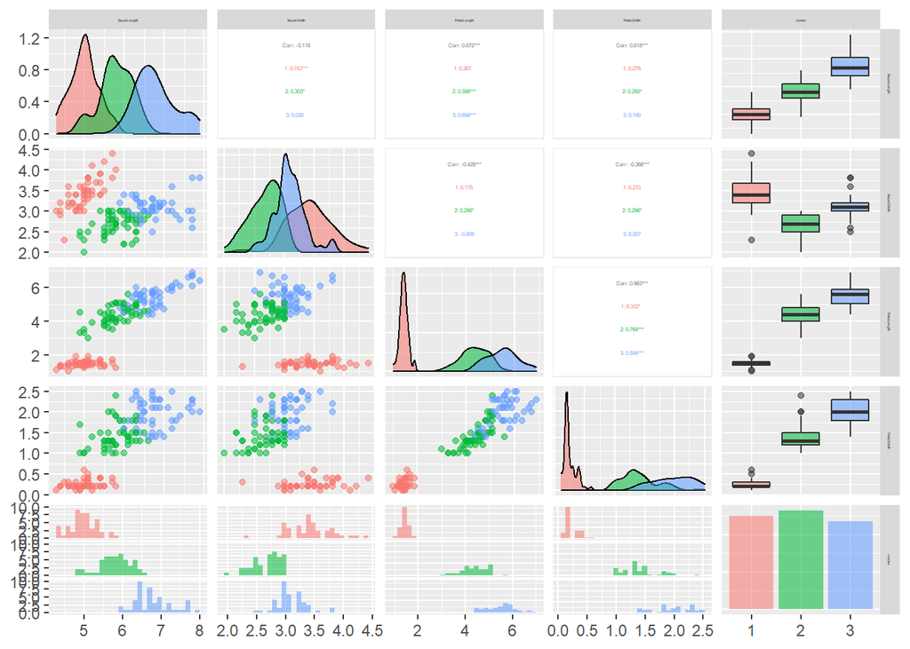

```r
ggpairs(data.clust.kmeans,aes(color=cluster, alpha=0.5),lower = list(combo = wrap("facethist"))
        ,upper = list(continuous = wrap('cor', size = 1)),binwidth = 0.1) + theme(strip.text = element_text(size = 2))
```

### k-medoids Kümelemesi

Özellikleri:

- k-ortalamalar ile ilişkili bir algoritmadır. Ancak, k-ortancalar de her küme, o gruptaki diğer tüm üyeler arasındaki ortalama farklılığı (ortanca) en aza indiren gözlemle temsil edilir.
- k-ortancalar, k-means’ten daha sağlam bir algoritma olarak kabul edilse de, gerçek klinik veri kümelerinde mutlaka daha iyi performans göstermez.

R paketleri:

- Cluster::pam() (Öklid ve Manhattan uzaklıklarını kullanır, sadece sayısal değişkenlere uygulanır)
- fpc::pamk() (Önerilen K’yi Silhouette göre yazdırır, kullanıcının küme sayısını tanımlamasını gerektirmez)

Avantajları:

- Uygulamak ve anlamak basit
- Gürültüye ve aykırı değerlere k-ortalamalar kümeleme algoritmasından daha az duyarlı
- Nesnelerin genel benzemezliğini kullanmaya izin vermesi

Dezavantajları:

- Küme sayılarının belirlenmesi gerekliliği
- Medoidlerin rasgele başlangıçlara duyarlılığı
- k-ortalamalar kümeleme algoritmasından daha yüksek hesaplama maliyetine sahip olma
- Küresel ve dışbükey kümeleri tanımlamaya daha yatkın
- Büyük veri kümeleri için iyi ölçeklenmemesi

k-ortancalar kümeleme algoritmasının büyük veri kümeleri ile başa çıkabilmesi için k-ortancalar (CLARA) algortiması oluşturuldu! Bu algoritma cluster::clara() fonksiyonunu kullanır.

Veri setine k-medoids kümelemesi uygulanırken öncelikle optimum küme sayısı bulunur.

1. Optimum küme sayısı (Elbow yöntemi):

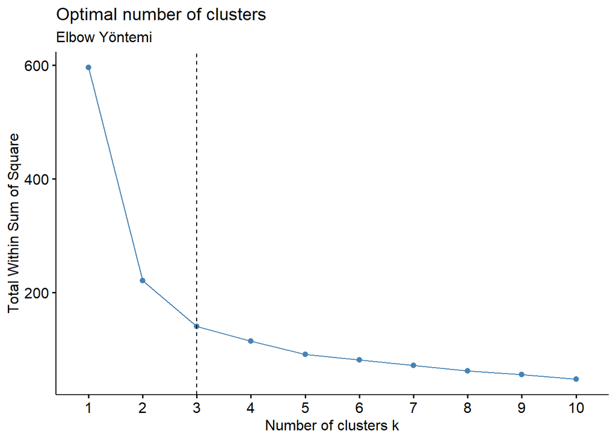

```r
# Elbow yöntemi
fviz_nbclust(data.scaled, pam, method = "wss") +
geom_vline(xintercept = 3, linetype = 2)+
labs(subtitle = "Elbow Yöntemi")
```

2. Optimum küme sayısı (Silhouette yöntemi):

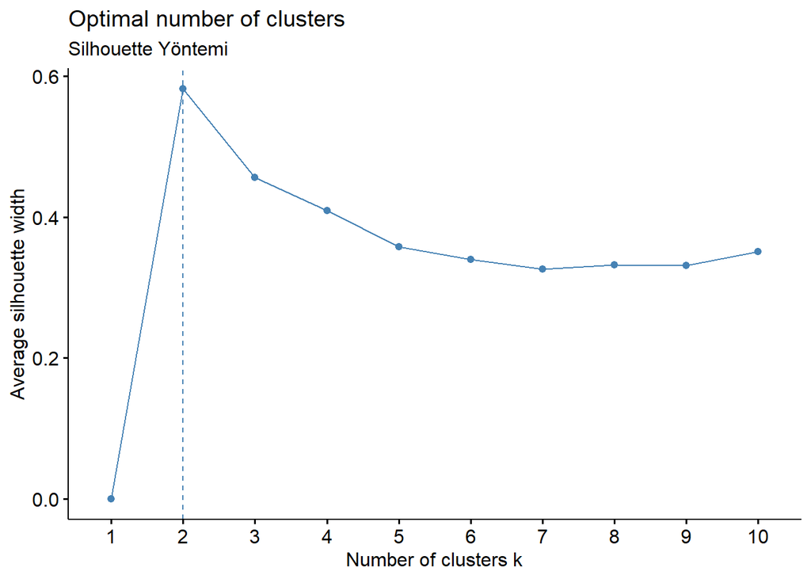

```r
# Silhouette yöntemi
fviz_nbclust(data.scaled, pam, method = "silhouette")+
labs(subtitle = "Silhouette Yöntemi")
```

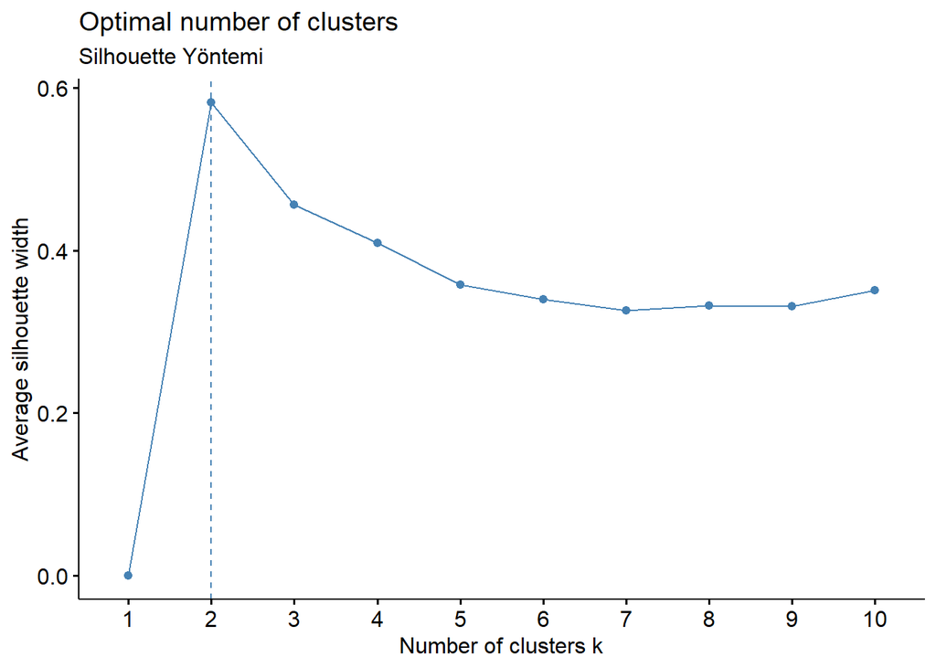

```r
# Gap istatistiği
fviz_nbclust(data.scaled, pam, method = "silhouette")+labs(subtitle = "Silhouette Yöntemi")
```

Veri seti için karar verilern küme sayısı 3’tür. k-medoid kümelemesi aşağıdaki gibi uygulanır.

```r
# k=3 ile k-medoid kümelemesi
pam.res <- pam(data.scaled, 3)
table(pam.res$cluster, iris[,5])
```

```
##
##     setosa versicolor virginica
##   1     50          0         0
##   2      0          9        36
##   3      0         41        14
```

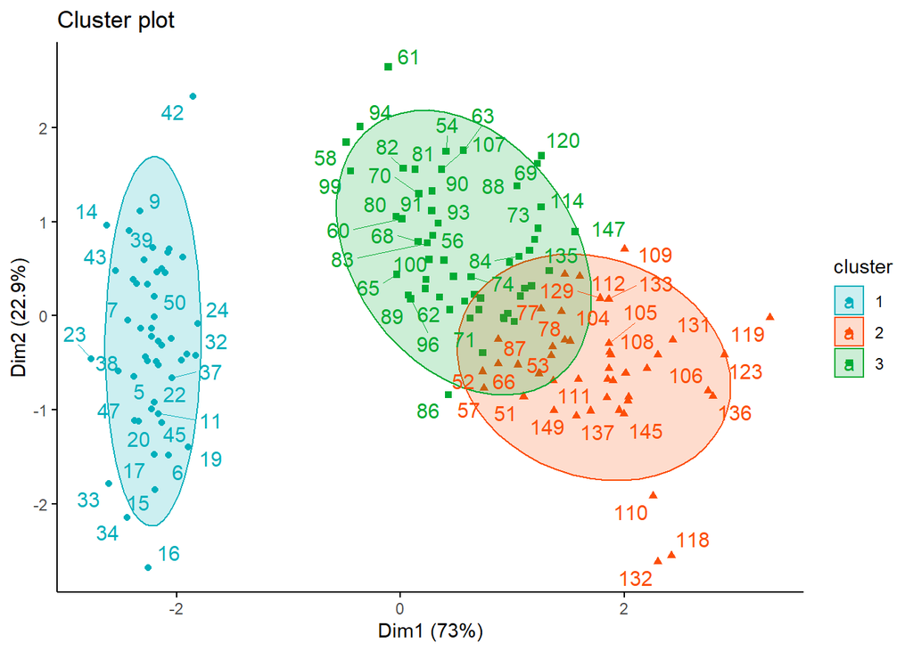

```r
# kümelerin görselleştirilmesi
fviz_cluster(pam.res,
palette = c("#00AFBB", "#FC4E07","#00AB33"),
ellipse.type = "t",
repel = TRUE,
ggtheme = theme_classic()
)
```

Ortalama için;

```r
# kümeler faktör haline getirilir
pam.res$cluster <- as.factor(pam.res$cluster)

# iris veri setine küme atanır
data.clust.pam <- cbind(data, cluster = pam.res$cluster)

# kümelenmiş verileri kümeye göre toplama
aggregate(data.clust.pam[,1:4], by=list(cluster=km.res$cluster), mean)%>%knitr::kable()
```

| cluster | Sepal.Length | Sepal.Width | Petal.Length | Petal.Width |
| --- | --- | --- | --- | --- |
| 1 | 5.006000 | 3.428000 | 1.462000 | 0.246000 |
| 2 | 5.801887 | 2.673585 | 4.369811 | 1.413207 |
| 3 | 6.780851 | 3.095745 | 5.510638 | 1.972340 |

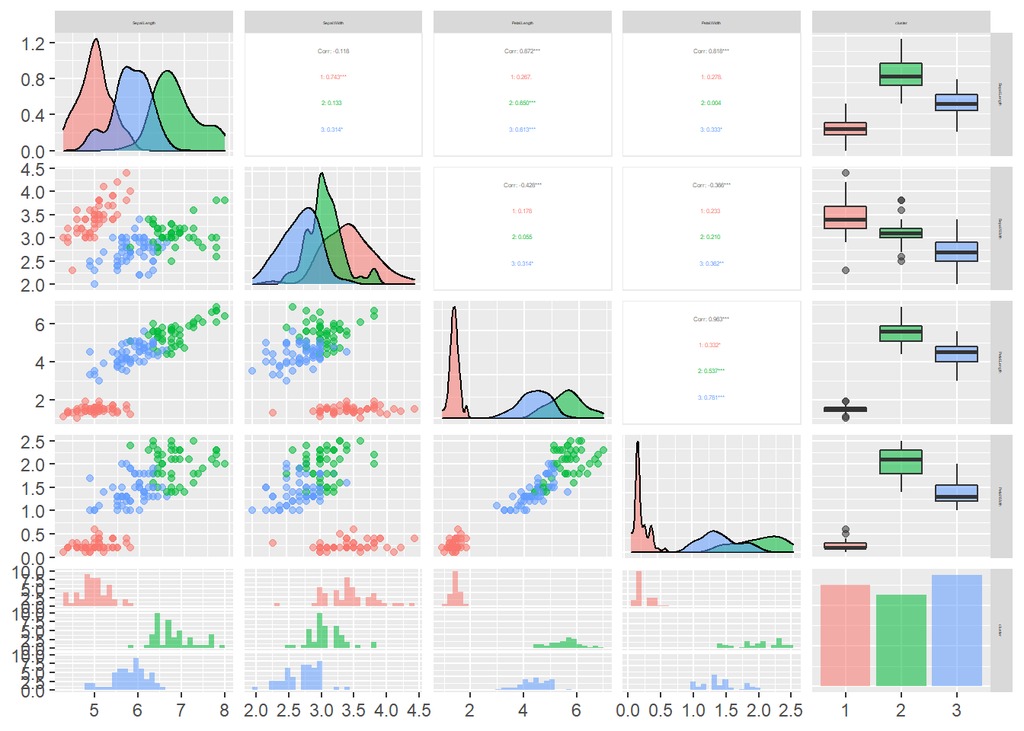

```r
ggpairs(data.clust.pam,aes(color=cluster, alpha=0.5),lower = list(combo = wrap("facethist"))
        ,upper = list(continuous = wrap('cor', size = 1)),binwidth = 0.1) + theme(strip.text = element_text(size = 2))
```

### Model-tabanlı Kümeleme

Özellikleri:

- İki veya daha fazla kümenin olasılık dağılımlarının bir karışımıdır.
- Bu metodoloji için EM algoritması, son karışım olasılıklarının parametrelerini tahmin etmek için en yaygın şekilde kullanılanıdır.
- Tıbbi görüntü alanındaki bazı klinik sorunları çözmek için başarıyla uygulanmıştır. Örneğin, bir EM kümeleme algoritması kullanan Hwang, Wireless Kapsül Endoskopi videolarında bağırsak kanama bölgelerini otomatik olarak tespit etmek için bir teknik önerdi.

R paketleri:

- mclust::mclust()

Avantajları:

- Uygulama basitliği
- Veriye bir model uydurabilme kabiliyeti
- Kümes sayısının önceden bilinmesini gerektirmeme
- Eksik değerlerle başedebilme

Dezavantajları:

- Yavaş yakınsama hızı
- Gözlem sayısı az olan ve eşdoğrusallık sorunları olan kümeler için uygun değildir

```r
mc<-Mclust(data.scaled)
mc$G
```

```
## [1] 2
```

```r
table(mc$classification, iris[,5])
```

```
##
##     setosa versicolor virginica
##   1     50          0         0
##   2      0         50        50
```

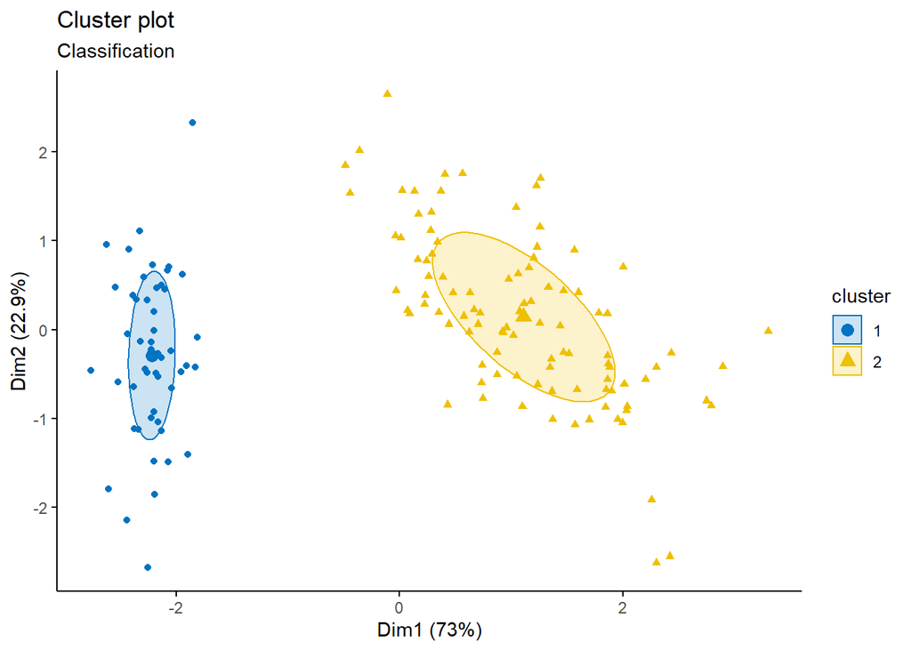

```r
# Classification: kümelemeyi göstererek grafikler
fviz_mclust(mc, "classification", geom = "point",pointsize = 1.5, palette = "jco")
```

```r
# kümeler faktör haline getirilir
mc$classification <- as.factor(mc$classification)

# orjinal veri seti kümelere atanır
data.clust.gmm <- cbind(data, cluster = mc$classification)

# kümelenmiş verileri kümeye göre toplama
aggregate(data.clust.gmm[,1:4], by=list(data.clust.gmm$cluster), mean)%>%knitr::kable()
```

| Group.1 | Sepal.Length | Sepal.Width | Petal.Length | Petal.Width |
| --- | --- | --- | --- | --- |
| 1 | 5.006 | 3.428 | 1.462 | 0.246 |
| 2 | 6.262 | 2.872 | 4.906 | 1.676 |

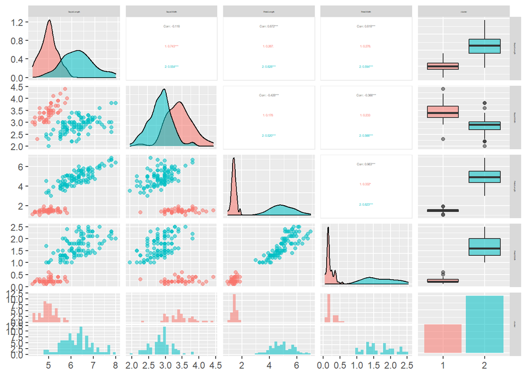

```r
ggpairs(data.clust.gmm,aes(color=cluster, alpha=0.5),lower = list(combo = wrap("facethist"))
        ,upper = list(continuous = wrap('cor', size = 1)),binwidth = 0.1) + theme(strip.text = element_text(size = 2))
```

### Hiyerarşik Kümeleme

Aşamalı bir yapıdan oluşur ve bir alt aşamadaki küme alt grupları bir sonraki aşamadaki kümeleri oluşturmak için bir araya getirilir. Uzaklık veya benzerlik ölçülerini dikkate alır.

- Birleştirici (agglomerative) aşamalı kümeleme yöntemi: Her gözlem başlangıçta tek başlarına ayrı birer küme olarak kabul edilir. Sonra, her adımda, en yakın iki gözlem yeni bir küme içinde birleştirilir. En sonunda, tüm bireyler bir küme içinde toplanır.
- Ayırıcı (divisive) aşamalı kümeleme yöntemi: Tüm gözlemler başlangıçta bir küme içerisindedir. Sonra, her adımda en farklı (uzak) gözlemler birbirinden ayrılarak daha küçük kümeler oluşturulur. En sonunda, her gözlem tek başına ayrı bir küme haline gelir.

Özellikleri:

- Klinikte en sık kullanılan kümeleme algoritmasıdır.
- Yığılımlı (bottom-up/agglomerative) ve bölücü (top-down/divisive) yaklaşımları kullanır.
- Bu iki yaklaşımdan biri ile birleştirilen kümeler genellikle ağaç grafiği (dendogram) ile sunulur.
- Küme sayısı belirlemede tercih edilir.
- Bir benzemezlik matrisi oluşturur.
- Biyoinformatikte omik alanda; klinikte Pulmonolojik, ramatolojik ve metabolik hastalıklar gibi çok farklı düzenlerdeki problemleri ele almada sıklıkla kullanılır.

R paketleri:

- Yığınsal Hiyerarşik Kümeleme: stat::hclust(), Cluster::agnes()
- Bölücü Hiyerarşik Kümeleme: cluster::diana()
- Dendextend paketi

Avantajları:

- Küme sayısının önceden bilinmesini gerektirmez
- Herhangi bir uzaklık fonksiyonu türünü kullanabilir
- Görsel bakımdan zengindir
- Küçük kümeleri tanımlamada yığınsal hiyerarşik kümeleme iyi iken, büyük kümeleri tanımlamada bölücü hiyerarşik kümeleme daha iyidir

Dezavantajları:

- Yüksek hesaplama maliyeti
- Analiz başladığında değişim yapmak çok zor
- Bağlantı fonksiyonlarına göre farklı küme sonuçları elde edebilir
- Küresel ve dışbükey kümeleri tanımlamaya daha yatkın
- Kofenetik mesafe kesmesini tanımlamak gerekliliği
- Aykırı değerlere duyarlılık

Linkage yöntemi küme sayısını etkiler.

1. Optimum küme sayısı (Elbow yöntemi):

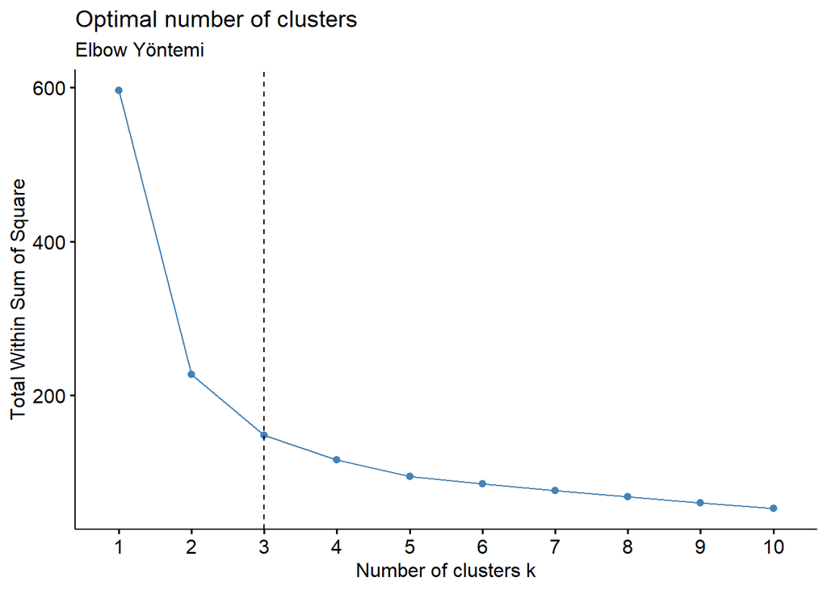

```r
# Elbow yöntemi
fviz_nbclust(data.scaled, hcut, method = "wss") +
geom_vline(xintercept = 3, linetype = 2)+
labs(subtitle = "Elbow Yöntemi")
```

2. Optimum küme sayısı (Silhouette yöntemi):

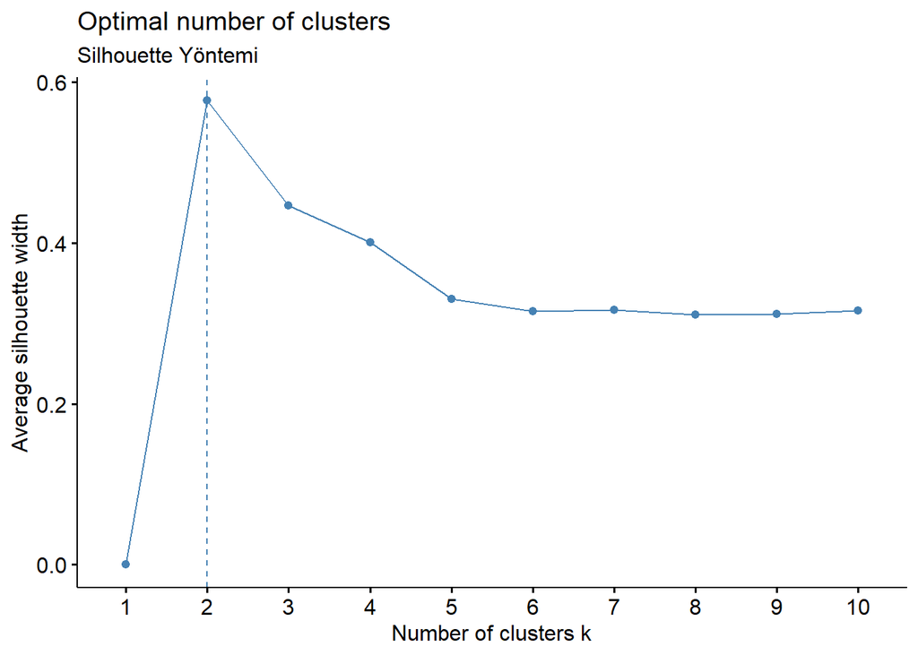

```r
# Silhouette yöntemi
fviz_nbclust(data.scaled, hcut, method = "silhouette")+
labs(subtitle = "Silhouette Yöntemi")
```

3. Optimum küme sayısı (Gap istatistiği):

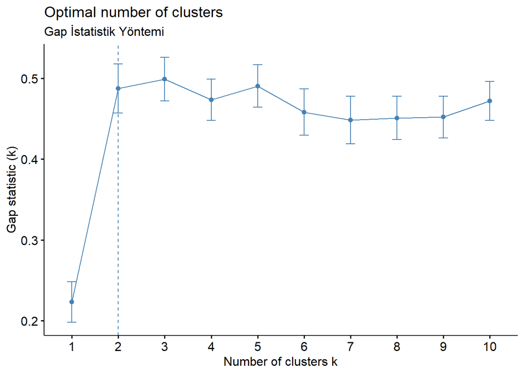

```r
# Gap istatistiği
set.seed(123)
fviz_nbclust(data.scaled, hcut, nstart = 25, method = "gap_stat",
nboot = 50)+
labs(subtitle = "Gap İstatistik Yöntemi")
```

Tam Bağlantı (Complete Linkage): Başlangıçta uzaklıklar matrisindeki en küçük uzaklık ile kümelemeye başlanır, ancak daha sonra, kümeleme sürecinde oluşturulacak yeni iki küme arasındaki uzaklık olarak kümelerdeki gözlemler arasındaki en büyük uzaklık dikkate alınır.

Çoğunluk kuralına göre “tam bağlantı (complete)” için hiyerarşik kümelemede optimum küme sayısı:

```r
# complete bağlantısı
nb.complete <- NbClust(data.scaled, distance = "euclidean", min.nc = 2,max.nc = 10, method = "complete", index = "ch")

# sonuçlar görselleştirilir
fviz_nbclust(nb.complete)
```

[output not shown]

```
## Number_clusters     Value_Index
##          3.0000        213.0817
```

Ward Yöntemi: En küçük varyans yöntemi olarak bilinir. Az gözlemli kümeleri birleştirme eğilimindedir. Ayrıca, eşit sayıda gözlemden oluşan kümeler oluşturma eğilimi de olduğundan daha çok birbirine yakın gözlem sayısına sahip kümeleme beklentilerinin olduğu durumlarda kullanılır.

Çoğunluk kuralına göre “ward bağlantı” için hiyerarşik kümelemede optimum küme sayısı:

```r
# ward bağlantısı
nb.ward2 <- NbClust(data.scaled, distance = "euclidean", min.nc = 2,max.nc = 10, method = "ward.D", index = "ch")
options(repr.plot.width=12, repr.plot.height=9)

# sonuçlar görselleştirilir
fviz_nbclust(nb.ward2)
```

[output not shown]

```
## Number_clusters     Value_Index
##          2.0000        240.2457
```

Ortalama Bağlantı (Average Linkage): Bir kümedeki tüm bireylerden elde edilen ortalama uzaklığın diğer kümedeki tüm bireylere olan ortalama uzaklığı kullanılarak hesaplanır.